# Re-analysis of the microarray data published by Murat, A. et al. (2008) “Stem Cell–Related “Self-Renewal” Signature and High Epidermal Growth Factor Receptor Expression Associated With Resistance to Concomitant Chemoradiotherapy in Glioblastoma”

### Álvaro Abella Bascarán (alvaro.abella01@estudiant.upf.edu)

### Eloi Casals (eloi.casals01@estudiant.upf.edu)

### Samuel Miravet Verde (samuel.miravet01@estudiant.upf.edu)

## Introduction

Glioblastoma multiforme is the most presented and aggressive brain tumor in humans, involving glial cells, with an incidence of 2–3 cases per 100,000 person life-years in Europe and North America ([Fonnet E. Bleeker, *et al* (2012)](http://www.ncbi.nlm.nih.gov/pmc/articles/PMC3337398/)).

Treatment can involve chemotherapy, radiation and surgery. Median survival with standard-of-care radiation and chemotherapy with the alkylating agent temozolomide is 15 months([Johnson, Derek R. *et al* (2011)](http://link.springer.com/article/10.1007%2Fs11060-011-0749-4)) while the median survival without treatment is 4 and a half months. Regretfully glioblastomas are notorious for resistance to therapy, which has been attributed to DNA-repair proficiency, a multitude of deregulated molecular pathways, and, more recently, to the particular biologic behavior of tumor stem-like cells. Here, based on the reference work of [Murat, A. *et al* (2008)](http://www.ncbi.nlm.nih.gov/pubmed/18565887), we aimed to identify the molecular profiles specific for treatment resistance to the current standard of care of concomitant chemoradiotherapy with temozolomide.

To achieve our goal, we take from the reference study a set of gene expression profiles of 80 glioblastomas of patients treated whithin clinical trials of concomitant and adjuvant temozolomide to radiotherapy (n=52) and patients treated with only radioterapy (n=28). In addition, 4 control patients were added to the study.

This document should be processed from R and you need to install the packages [knitr](http://cran.r-project.org/web/packages/knitr/index.html) and [markdown](http://cran.r-project.org/web/packages/markdown/index.html). Once they are installed, you have to type the following instructions that generate a HTML document that you can open with a web browser:

```
library(knitr)     ## required for "knitting" from Rmd to md
library(markdown)  ## required for processing from md to HTML
knit("projectTemplate.Rmd", "projectTemplate.md")  ## process Rmd to md
markdownToHTML("projectTemplate.md", "projectTemplate.html") ## process md to HTML
browseURL("projectTemplate.html") ## open the resulting HTML file from R
```

## Data

The microarray data used during the research of [Murat, A. *et al* (2008)](http://www.ncbi.nlm.nih.gov/pubmed/18565887) can be found at the [Gene Expression Omnibus](http://www.ncbi.nlm.nih.gov/geo/), with the accession number GSE7696. In order to proceed with this analysis, the file [GSE7696_RAW.tar](http://www.ncbi.nlm.nih.gov/geo/download/?acc=GSE7696&format=file) must be uncompressed under the directory ‘data/raw/’ and the file GSE7696_series_matrix.txt.gz must be placed inside ‘data/’.

```r
qaDiag <- data.frame(RawDist = rep(FALSE, ncol(eset)), PLMresids = rep(FALSE, ncol(eset)), NUSE = rep(FALSE, ncol(eset)), RLE = rep(FALSE, ncol(eset)), MA = rep(FALSE, ncol(eset)), Failed = rep(0, ncol(eset)), row.names = sampleNames(glioData))

qaDiag[badSamplesRawDist, "RawDist"] <- TRUE
qaDiag[badSamplesPLMResids, "PLMresids"] <- TRUE
qaDiag[badSamplesNUSE, "NUSE"] <- TRUE
qaDiag[badSamplesRLE, "RLE"] <- TRUE
qaDiag[badSamplesMA, "MA"] <- TRUE

qaDiag$Failed <- rowSums(qaDiag)
qaDiag <- qaDiag[order(qaDiag$Failed, decreasing = TRUE), ]
qaDiag
```

```
##   RawDist PLMresids  NUSE   RLE    MA Failed
## u    TRUE     FALSE  TRUE FALSE FALSE      2
## c   FALSE     FALSE FALSE FALSE  TRUE      1
## d   FALSE     FALSE FALSE FALSE  TRUE      1
## j   FALSE      TRUE FALSE FALSE FALSE      1
## o   FALSE     FALSE FALSE FALSE  TRUE      1
## a   FALSE     FALSE FALSE FALSE FALSE      0
## b   FALSE     FALSE FALSE FALSE FALSE      0
## e   FALSE     FALSE FALSE FALSE FALSE      0
## f   FALSE     FALSE FALSE FALSE FALSE      0
## g   FALSE     FALSE FALSE FALSE FALSE      0
## h   FALSE     FALSE FALSE FALSE FALSE      0
## i   FALSE     FALSE FALSE FALSE FALSE      0
## k   FALSE     FALSE FALSE FALSE FALSE      0
## l   FALSE     FALSE FALSE FALSE FALSE      0
## m   FALSE     FALSE FALSE FALSE FALSE      0
## n   FALSE     FALSE FALSE FALSE FALSE      0
## p   FALSE     FALSE FALSE FALSE FALSE      0
## q   FALSE     FALSE FALSE FALSE FALSE      0
## r   FALSE     FALSE FALSE FALSE FALSE      0
## s   FALSE     FALSE FALSE FALSE FALSE      0
## t   FALSE     FALSE FALSE FALSE FALSE      0
```

## Batch identification

The main goal of this step consists in finding if there exist any possible batch effect in our dataset, that is technical sources of variation that have been added to the samples during handling ([Leek, *et al* (2010)](http://www.nature.com/nrg/journal/v11/n10/full/nrg2825.html#close)). It is important to detect them in order to ensure that the possible future differences between expressions do not come from a non-biological or scientific variables source.

After loading the needed libraries, we start the process retrieving the expression set of study and giving a specific letter to each sample.

```r
library(affy)
library(Biobase)
library(GEOquery)
library(affyPLM)
library(corpcor)

# glioData = readRDS('glioData.rds')
# eset = readRDS('eset.rds')
# sampleNames(glioData) = letters[1:21]
```

Between all the different features our dataset have, the only possible batch source is the experiment date of each sample so this will be our batch grouping variable. To consider it, we have to set a scanDate variable in the correct format:

```r
scanDate = protocolData(glioData)$ScanDate
scanDate = gsub(" .*", "", scanDate)
scanDate = as.Date(scanDate, "%m/%d/%y")
```

Once defined that variable, we are already able to group together the samples obtained in the same date:

```r
minscan = min(scanDate)
days = scanDate- minscan

sort(days)
```

```
## Time differences in days
##  [1]   0   0   2   2   2   2   3   3   3   3   3   7   7   7   7   7  10
## [18]  10  10  10 192
```

With those different day groups we can discretize the days numeric variable into desired intervals to finally obtain our surrogate batch indicator variable. In addition, the length of the variable *days* allows us to define a vector of colors that will be used in the posterior plots.

```r
batch_days = data.frame(row.names=sort(unique(days)), batch=c(1:length(unique(days))))

ourcolors = rainbow(length(unique(days)))
```

The differential outcome for our dataset is the survival time as the aim of the study is to define a set of genes expressed differentially between resistant cancer patients and non-resistant. To consider it, we extract the variable from the *eset* and transform it into a character string.

```r
survival_time = eset$characteristics_ch1.7
survival_time = gsub('.*:', '', survival_time)
survival_time = as.character(survival_time)
```

The division of our outcome respect the batch groups can be resumed with the *table* function:

```r
table(data.frame(Outcome = survival_time, Batch = days))
```

```
##         Batch
## Outcome  0 2 3 7 10 192
##    10.43 0 1 0 0  0   0
##    11.84 0 0 0 1  0   0
##    14.41 0 0 1 0  0   0
##    15.53 0 0 1 0  0   0
##    15.99 0 0 1 0  0   0
##    16.22 0 0 0 0  1   0
##    16.28 0 0 0 1  0   0
##    17.07 0 0 0 0  1   0
##    17.34 1 0 0 0  0   0
##    22.89 0 0 0 0  1   0
##    24.41 0 1 0 0  0   0
##    25.13 0 0 0 0  0   1
##    28.22 0 0 0 1  0   0
##    36.45 0 0 1 0  0   0
##    4.44  0 0 1 0  0   0
##    46.55 0 0 0 1  0   0
##    5.95  0 0 0 1  0   0
##    7.5   1 0 0 0  0   0
##    8.06  0 1 0 0  0   0
##    8.75  0 1 0 0  0   0
##    NA    0 0 0 0  1   0
```

#### Hierarchical Clustering

A nice way to see how effectively batch is confounding the outcome of interest consists of doing a hierarchical clustering of the samples indicating the batch to which each of them belongs to. We should start by calculating the distance between every pair of samples using a non-parametric association measure such as [Spearman correlation](http://en.wikipedia.org/wiki/Spearman%27s_rank_correlation_coefficient):

```r
d = as.dist(1 - cor(exprs(eset), method="spearman"))
```

Using *hclust* we perform the hierarchical clustering which can be easily understood showing it in a [dendrogram](http://en.wikipedia.org/wiki/Dendrogram).

```r
# Hierarchical analysis:

sampleClustering = hclust(d)

# Function to generate the dendrogram:

sampleDendrogram = as.dendrogram(sampleClustering, hang=0.5)
batch = days
names(batch) = sampleNames(eset)
names(survival_time) = sampleNames(eset)
sampleDendrogram = dendrapply(sampleDendrogram, function(x, batch, labels) {
    ## for every node in the dendrogram if it is a leaf node
    if (is.leaf(x)) {
      print(x)
        attr(x, "nodePar") = list(lab.col = as.vector(ourcolors[batch_days[as.character(batch[attr(x, "label")]),]]))
        attr(x, "label") = as.vector(labels[attr(x, "label")])  ## label by survival_time
    }
    x
}, batch, survival_time)
```

[output not shown]

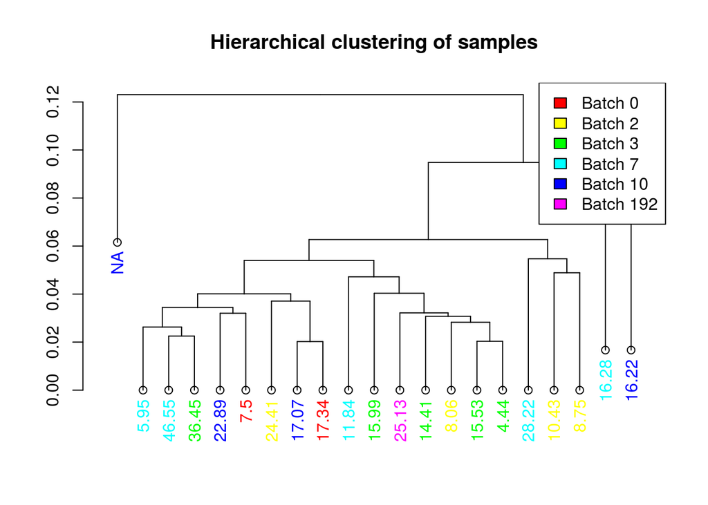

```r
# And the required command to plot it:

plot(sampleDendrogram, main = "Hierarchical clustering of samples")
legend("topright", paste("Batch", sort(unique(batch))), fill = ourcolors)
```

In the dendrogram we are able to see how there does not exist any batch effect confounding our outcome as the different survival times are randomly distributed and the colors (representing the batch group) do not cluster in concrete branches.

#### Multidimensional Scaling

Another way to verify whether batch is the main source of variation is [multidimensional scaling](http://en.wikipedia.org/wiki/Multidimensional_scaling) analysis. To perform it, we have to run the function *cmdscale*. The resulting *cmd* object have to be a matrix of dimension (n,2) where n=number of samples.

```r
cmd = cmdscale(as.dist(1 - cor(exprs(eset), method = "spearman")))

dim(cmd)
```

```
## [1] 21  2
```

```r
head(cmd)
```

```
##                   [,1]          [,2]
## GSM187180  0.075935177  0.0243188995
## GSM187213 -0.001443038 -0.0000049331
## GSM187178 -0.017200821 -0.0137915294
## GSM187175 -0.011023521 -0.0132489966
## GSM187232  0.016500092 -0.0032648222
## GSM187163  0.021697818 -0.0024718422
```

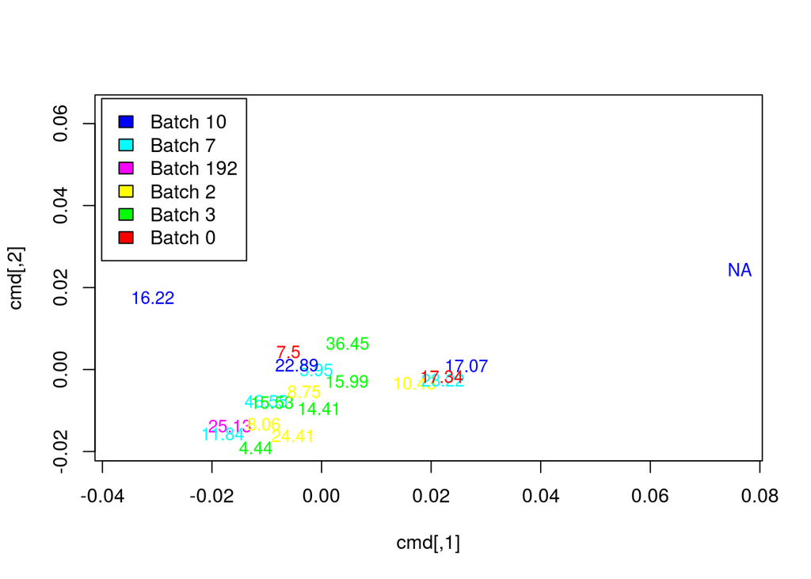

```r
# Ploting the result
plot(cmd, type = "n")
text(cmd, survival_time, col = ourcolors[batch_days[as.character(batch),]], cex = 0.9)
legend("topleft", paste("Batch", unique(batch)), fill = ourcolors[batch_days[as.character(unique(batch)),]], inset = 0.01)
```

All the survival times are mixed well and we cannot detect any color group in the distribution meaning that there is no bacth effect that could confound a possible differential classification of the outcome.

#### Quantifying Confounding

The last test we are going to perform is the quantification of confounding between batch and outcome by means of a [Principal Component Analysis](http://en.wikipedia.org/wiki/Principal_component_analysis) test. It works rebuilding the data set in new variables (Principal Components) in terms of linear combinations, such that they capture most of the variance of the data. The purpose of applying PCA in this case is to compare the principal components that account for the largest variability of the data, to known variables such as a batch indicator.

We start the process computing the [single value decomposition](http://en.wikipedia.org/wiki/Singular_value_decomposition) (SVD) of the data:

```r
s = fast.svd(t(scale(t(exprs(eset)), center=TRUE, scale=TRUE)))
```

This value allows us to plot the fraction of variance explained by each principal component as follows:

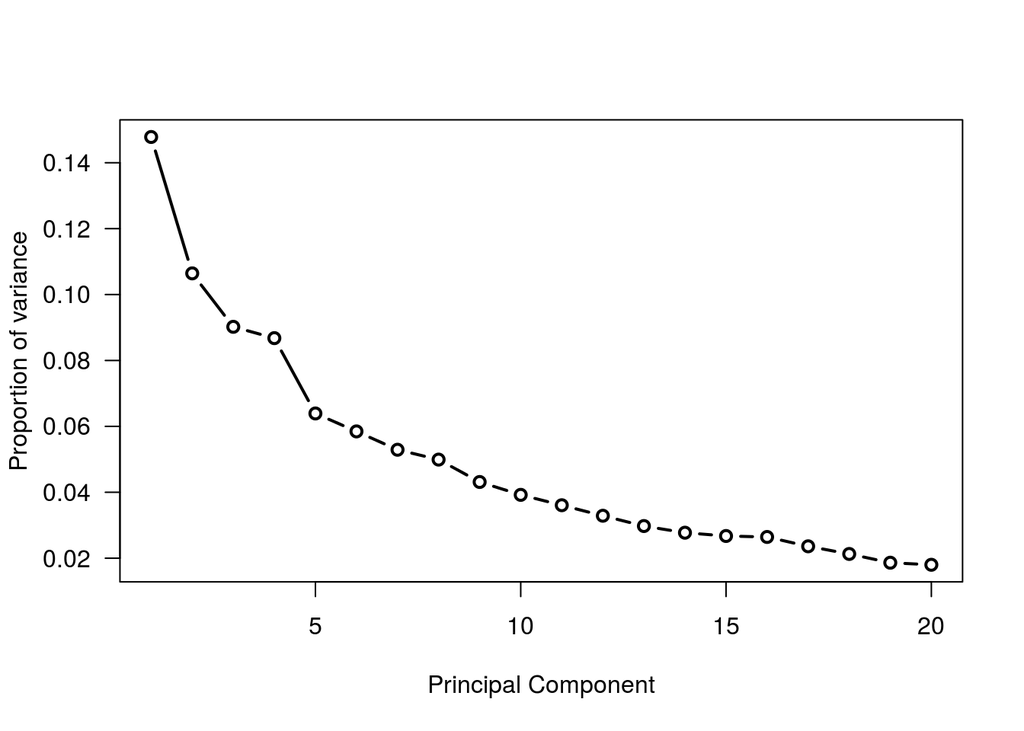

```r
plot(s$d^2/sum(s$d^2), type="b", lwd=2, las=1, xlab="Principal Component", ylab="Proportion of variance")
```

Using the function *cumsum* we can evaluate the amount variance accumulated with each principal component:

```r
head(cumsum(s$d^2/sum(s$d^2)))
```

```
## [1] 0.1478175 0.2542525 0.3444673 0.4312466 0.4951665 0.5536456
```